# main_file

- This section analyzes how salaries vary across different experience levels
- The goal is to identify which experience levels receive the highest and lowest compensation
- This helps understand salary progression across career stages in the data job market

```python
#step01: Calculated Median Salary by Experience Level

median_salary_by_experience = (
    clean_dataset.groupby("experience_level")["salary_in_usd"]
    .median().reset_index(name="median_salary")
    .sort_values("median_salary", ascending=False)
)
median_salary_by_experience
```

|  | experience_level | median_salary |
| --- | --- | --- |
| 1 | Executive-level | 184560.0 |
| 3 | Senior-level | 153600.0 |
| 2 | Mid-level | 106500.0 |
| 0 | Entry-level | 75000.0 |

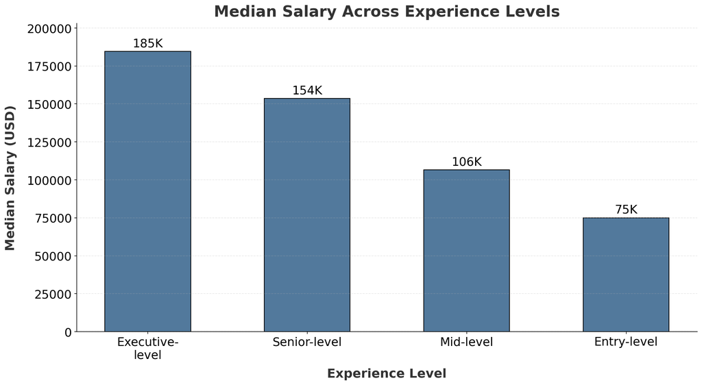

```python
#step02: Visualized median salary (USD) Across Experience Levels

# Data
x = median_salary_by_experience["experience_level"]
y = median_salary_by_experience["median_salary"]

# Wrap long labels for better readability
import textwrap
wrapped_labels = [textwrap.fill(label, 12) for label in x]

# Create positions to increase spacing between bars
pos = np.arange(len(x)) * 1.3

# Create figure
plt.figure(figsize=(16, 8), dpi=150)

# Bar plot
plt.bar(pos, y, width=0.7, edgecolor="black", color="#52799C")

# Titles and labels
plt.title(
    "Median Salary Across Experience Levels",
    color="#333333",
    fontweight="bold",
    fontsize=22,
    pad=10
)
plt.xlabel("Experience Level", fontweight="bold", fontsize=18, labelpad=10, color="#333333")
plt.ylabel("Median Salary (USD)", fontweight="bold", fontsize=18, labelpad=14, color="#333333")

# Axis formatting
plt.xticks(pos, wrapped_labels, fontsize=17)
plt.yticks(fontsize=17)

# Add value labels (formatted as K)
for i, v in enumerate(y):
    label = f"{v/1000:.0f}K"
    plt.text(
        pos[i],
        v + max(y) * 0.008,
        label,
        ha='center',
        va='bottom',
        fontsize=17
    )

# Styling improvements
plt.ylim(0, max(y) * 1.1)
plt.margins(y=0.05)
plt.grid(axis='y', linestyle='--', alpha=0.3)

# Remove unnecessary borders
plt.gca().spines['top'].set_visible(False)
plt.gca().spines['right'].set_visible(False)

# Show plot
plt.show()
```

KEY INSIGHTS OF EDA SECTION 09:

- Executive-level roles have the highest median salary (~184K), reflecting premium pay for leadership positions.
- Senior-level professionals earn significantly higher salaries (~154K) than mid and entry-level roles.
- Mid-level salaries (~106K) show strong growth from entry-level, highlighting career progression benefits.
- Entry-level roles have the lowest median salary (~75K), representing the starting stage of data careers.

RELATIONSHIP INSIGHTS – EDA SECTION 08 & 09

- Senior-level roles show the highest job demand along with strong salary levels, making them the most balanced career stage.
- Executive-level roles have the highest salaries but the lowest demand, reflecting fewer but highly paid leadership positions.
- Mid-level roles maintain steady demand and salary growth, indicating strong career progression opportunities.
- Entry-level roles have lower demand and the lowest salaries, showing limited openings for freshers in the market.
- Overall: higher experience levels are associated with higher salaries, but not always with higher job demand.

EDA SECTION 10: Work Model Preferences Across Data Domains

- This section analyzes how work models vary across different data domains
- The goal is to identify which domains prefer remote, hybrid, or on-site work
- This helps understand workplace trends and flexibility across data roles

```python
# STEP 01: Calculated Work Mode Preferences Across Data Domains

work_mode_preferences = (
    clean_dataset.groupby(["job_category", "work_models"])
    .size()
    .reset_index(name="work_mode_count")
)

# sort within each domain by work_model_count (desc)
sorted_df = work_mode_preferences.sort_values(
    ["job_category", "work_mode_count"],
    ascending=[True, False]
)

sorted_df
```

|  | job_category | work_models | work_mode_count |
| --- | --- | --- | --- |
| 1 | Business Intelligence | On-site | 167 |
| 2 | Business Intelligence | Remote | 82 |
| 0 | Business Intelligence | Hybrid | 1 |
| 4 | Data Analysis | On-site | 720 |
| 5 | Data Analysis | Remote | 581 |
| 3 | Data Analysis | Hybrid | 34 |
| 7 | Data Architecture | On-site | 114 |
| 8 | Data Architecture | Remote | 90 |
| 6 | Data Architecture | Hybrid | 2 |
| 10 | Data Engineering | On-site | 786 |
| 11 | Data Engineering | Remote | 599 |
| 9 | Data Engineering | Hybrid | 33 |
| 13 | Data Science | On-site | 1019 |
| 14 | Data Science | Remote | 637 |
| 12 | Data Science | Hybrid | 77 |
| 16 | Leadership & Management | On-site | 201 |
| 17 | Leadership & Management | Remote | 155 |
| 15 | Leadership & Management | Hybrid | 33 |
| 19 | Machine Learning & AI | On-site | 566 |
| 20 | Machine Learning & AI | Remote | 355 |
| 18 | Machine Learning & AI | Hybrid | 34 |
| 22 | Other | On-site | 233 |
| 23 | Other | Remote | 60 |
| 21 | Other | Hybrid | 11 |

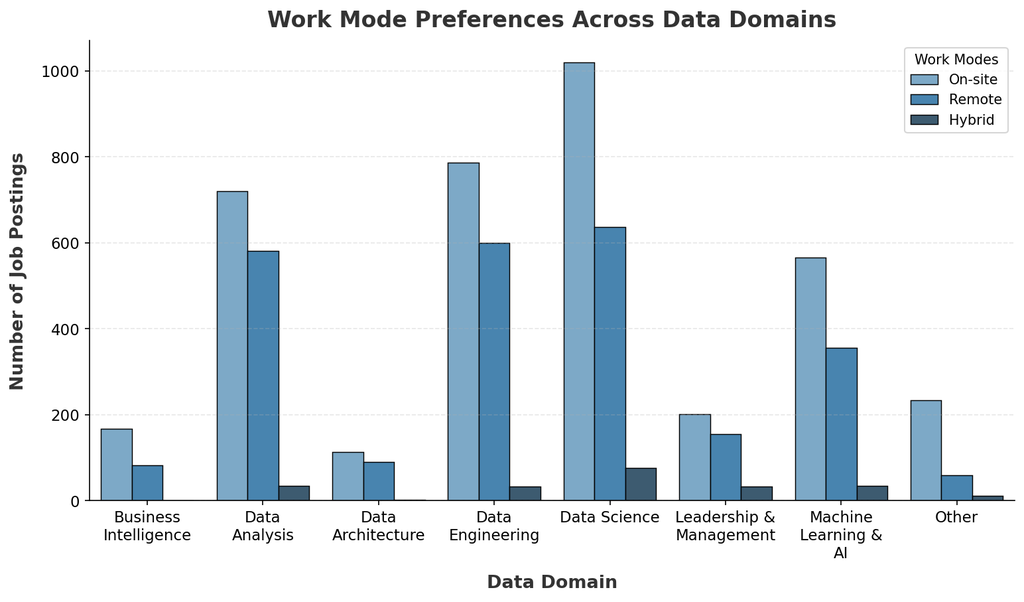

```python
#step02: visualized how different data domains prefer work modes (On-site, Remote, Hybrid)

# Set figure size and resolution for better clarity
plt.figure(figsize=(12, 6), dpi=150)

# Create bar plot to compare job categories vs work model counts
ax = sns.barplot(
    data=sorted_df,
    x="job_category",
    y="work_mode_count",
    hue="work_models",              # separates bars by work type (Remote/On-site/Hybrid)
    palette="Blues_d",              # blue color theme for clean visual look
    width=0.8,                      # controls bar thickness
    edgecolor="black",              # adds border to bars
    linewidth=0.7                   # border thickness
)

# Add chart title
plt.title(
    "Work Mode Preferences Across Data Domains",
    fontsize=16,
    fontweight="bold",
    color="#333333",
    pad=10
)

# X-axis label
plt.xlabel(
    "Data Domain",
    fontsize=13,
    fontweight="bold",
    color="#333333",
    labelpad=10
)

# Y-axis label
plt.ylabel(
    "Number of Job Postings",
    fontsize=13,
    fontweight="bold",
    color="#333333",
    labelpad=10
)

# Wrap long x-axis labels to improve readability
import textwrap
ax.set_xticks(ax.get_xticks())
ax.set_xticklabels(
    [textwrap.fill(label.get_text(), 12) for label in ax.get_xticklabels()],
    rotation=0
)

# Adjust tick label sizes
ax.tick_params(axis='x', labelsize=11)
ax.tick_params(axis='y', labelsize=11)

# Add legend for work model categories
ax.legend(title="Work Modes")

# Add light grid lines for better readability of values
plt.grid(axis='y', linestyle='--', alpha=0.3)

# Remove unnecessary plot borders (top and right)
plt.gca().spines['top'].set_visible(False)
plt.gca().spines['right'].set_visible(False)

# Display final plot
plt.show()
```

KEY INSIGHTS OF EDA SECTION 10:

- On-site work mode dominates across all data domains, especially in Data Science and Data Engineering
- Remote work mode is the second most common option, showing strong demand for flexible roles in tech fields
- Hybrid work mode is minimal across all domains, indicating it is still not widely adopted in data-related jobs

EDA SECTION 11: Median Salary by Work Mode

- This section analyzes salary differences across Remote, Hybrid, and On-site jobs
- The goal is to check which work model offers higher median salaries
- This helps understand whether flexible work options are linked to better pay in data jobs

```python
#step01: Calculated median salary for each work model

median_salary_workmode = (clean_dataset.groupby("work_models")
                            ["salary_in_usd"].median()
                            .reset_index(name="median_salary")
                            .sort_values("median_salary", ascending=False))
median_salary_workmode
```

|  | work_models | median_salary |
| --- | --- | --- |
| 1 | On-site | 142200.0 |
| 2 | Remote | 136000.0 |
| 0 | Hybrid | 66192.0 |

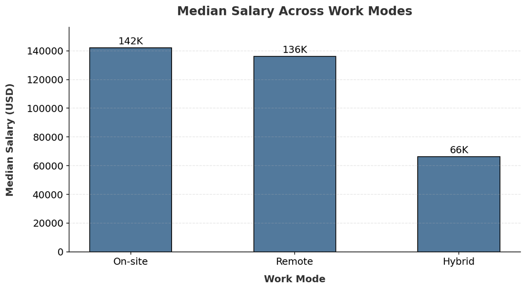

```python
#step02: Visualized median salary across different work models using a bar chart for salary comparison

# Data
x = median_salary_workmode["work_models"]
y = median_salary_workmode["median_salary"]

# Create figure
plt.figure(figsize=(10, 5), dpi=150)

# Bar plot
plt.bar(x, y, width=0.5, edgecolor="black", color="#52799C")

# Titles and labels
plt.title(
    "Median Salary Across Work Modes",
    color="#333333",
    fontweight="bold",
    fontsize=15,
    pad=15
)
plt.xlabel("Work Mode", fontweight="bold", fontsize=12, labelpad=10, color="#333333")
plt.ylabel("Median Salary (USD)", fontweight="bold", fontsize=12, labelpad=14, color="#333333")

# Axis formatting
plt.xticks(fontsize=12)
plt.yticks(fontsize=12)

# Add value labels (formatted as K)
for i, v in enumerate(y):
    label = f"{v/1000:.0f}K"
    plt.text(
        i,
        v + max(y) * 0.008,
        label,
        ha='center',
        va='bottom',
        fontsize=12
    )

# Styling improvements
plt.ylim(0, max(y) * 1.1)
plt.margins(y=0.05)
plt.grid(axis='y', linestyle='--', alpha=0.3)

# Remove unnecessary borders
plt.gca().spines['top'].set_visible(False)
plt.gca().spines['right'].set_visible(False)
# Show plot
plt.show()
```

KEY INSIGHTS OF EDA SECTION 11:

- Even though On-site work dominates across all data domains (EDA 10), it also offers the highest median salary (EDA 11), showing strong consistency between demand and pay
- Remote work is the second most common work mode and also provides nearly similar salaries to On-site roles, making it a strong flexible and high-paying option
- Hybrid work is both the least adopted (EDA 10) and lowest paying (EDA 11), indicating it is the weakest work mode in both demand and compensation

```python
#step01: Calculated top 10 company locations with highest median salaries

median_salary_bylocation = (clean_dataset
                            .groupby("company_location")
                            ["salary_in_usd"].median()
                            .reset_index(name="median_salary")
                            .sort_values("median_salary", ascending=False)
                            .head(10))

median_salary_bylocation
```

|  | company_location | median_salary |
| --- | --- | --- |
| 57 | Qatar | 300000.0 |
| 56 | Puerto Rico | 167500.0 |
| 73 | United States | 148000.0 |
| 60 | Saudi Arabia | 134999.0 |
| 10 | Canada | 133700.0 |
| 49 | New Zealand | 125000.0 |
| 8 | Bosnia and Herzegovina | 120000.0 |
| 35 | Israel | 119059.0 |
| 71 | United Arab Emirates | 115000.0 |
| 67 | Switzerland | 104360.5 |

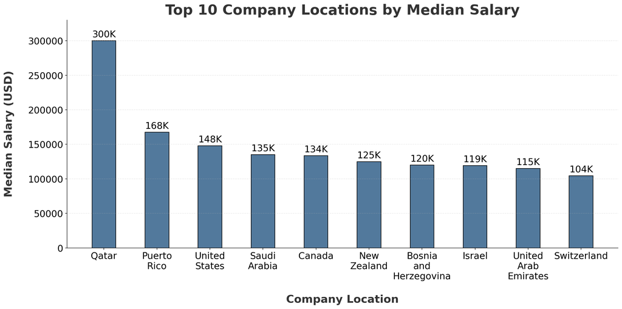

```python
#step02: Visualized top-paying company locations by Median salary

# Data
x = median_salary_bylocation["company_location"]
y = median_salary_bylocation["median_salary"]

# Wrap long labels for better readability
import textwrap
wrapped_labels = ["\n".join(label.split()) for label in x]

# Create positions to increase spacing between bars
pos = np.arange(len(x)) * 2.0   # adjust (1.3–1.5) for more spacing

# Create figure
plt.figure(figsize=(16, 8), dpi=150)

# Bar plot
plt.bar(pos, y, width=0.9, edgecolor="black", color="#52799C")

# Titles and labels
plt.title(
    "Top 10 Company Locations by Median Salary",
    color="#333333",
    fontweight="bold",
    fontsize=26,
    pad=10
)
plt.xlabel("Company Location", fontweight="bold", fontsize=20, labelpad=25, color="#333333")
plt.ylabel("Median Salary (USD)", fontweight="bold", fontsize=20, labelpad=25, color="#333333")

# Axis formatting
plt.xticks(pos, wrapped_labels, fontsize=17)
plt.yticks(fontsize=17)

# Add value labels (formatted as K)
for i, v in enumerate(y):
    label = f"{v/1000:.0f}K"   # 400000 → 400K
    plt.text(
        pos[i],
        v + max(y) * 0.008,
        label,
        ha='center',
        va='bottom',
        fontsize=17
    )

# Styling improvements
plt.ylim(0, max(y) * 1.1)
plt.margins(y=0.05)
plt.grid(axis='y', linestyle='--', alpha=0.3)

# Remove unnecessary borders
plt.gca().spines['top'].set_visible(False)
plt.gca().spines['right'].set_visible(False)

# Show plot
plt.tight_layout()
plt.show()
```

KEY INSIGHTS OF EDA SECTION 12:

- Qatar has the highest median salary among all locations, standing out as the top-paying country
- Puerto Rico, United States, Saudi Arabia, and Canada also offer high-paying data job opportunities
- High salaries are spread across different countries, showing that top-paying roles are not limited to one region

EDA SECTION 13: Company Size Hiring Distribution Across Data Domains

- This section analyzes how job opportunities are distributed across company sizes (Small, Medium, Large) within different data domains
- The goal is to see which company size hires the most in each domain
- This helps understand hiring patterns based on company scale in data roles

```python
#step01: Calculate job count by company size across each job category

company_size_hiring_count = (clean_dataset
                            .groupby(["job_category", "company_size"])
                            .size()
                            .reset_index(name="job_count")
                            .sort_values(["job_category", "job_count"], ascending=[True, False]))

company_size_hiring_count
```

|  | job_category | company_size | job_count |
| --- | --- | --- | --- |
| 1 | Business Intelligence | Medium | 230 |
| 0 | Business Intelligence | Large | 19 |
| 2 | Business Intelligence | Small | 1 |
| 4 | Data Analysis | Medium | 1219 |
| 3 | Data Analysis | Large | 87 |
| 5 | Data Analysis | Small | 29 |
| 7 | Data Architecture | Medium | 194 |
| 6 | Data Architecture | Large | 12 |
| 9 | Data Engineering | Medium | 1312 |
| 8 | Data Engineering | Large | 91 |
| 10 | Data Engineering | Small | 15 |
| 12 | Data Science | Medium | 1490 |
| 11 | Data Science | Large | 191 |
| 13 | Data Science | Small | 52 |
| 15 | Leadership & Management | Medium | 294 |
| 14 | Leadership & Management | Large | 78 |
| 16 | Leadership & Management | Small | 17 |
| 18 | Machine Learning & AI | Medium | 832 |
| 17 | Machine Learning & AI | Large | 75 |
| 19 | Machine Learning & AI | Small | 48 |
| 21 | Other | Medium | 280 |
| 20 | Other | Large | 16 |
| 22 | Other | Small | 8 |

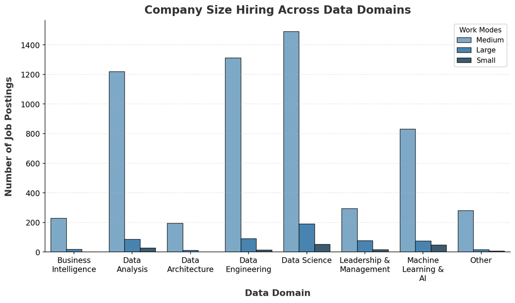

```python
#step02: Visualized how company sizes (Small, Medium, Large) hire across data domains

# Set figure size and resolution for better clarity
plt.figure(figsize=(12, 6), dpi=150)

# Create bar plot to compare job categories vs work model counts
ax = sns.barplot(
    data=company_size_hiring_count,
    x="job_category",
    y="job_count",
    hue="company_size",              # separates bars by work type (Remote/On-site/Hybrid)
    palette="Blues_d",              # blue color theme for clean visual look
    width=0.8,                      # controls bar thickness
    edgecolor="black",              # adds border to bars
    linewidth=0.7                   # border thickness
)

# Add chart title
plt.title(
    "Company Size Hiring Across Data Domains",
    fontsize=16,
    fontweight="bold",
    color="#333333",
    pad=10
)

# X-axis label
plt.xlabel(
    "Data Domain",
    fontsize=13,
    fontweight="bold",
    color="#333333",
    labelpad=10
)

# Y-axis label
plt.ylabel(
    "Number of Job Postings",
    fontsize=13,
    fontweight="bold",
    color="#333333",
    labelpad=10
)

# Wrap long x-axis labels to improve readability
import textwrap
ax.set_xticks(ax.get_xticks())
ax.set_xticklabels(
    [textwrap.fill(label.get_text(), 12) for label in ax.get_xticklabels()],
    rotation=0
)

# Adjust tick label sizes
ax.tick_params(axis='x', labelsize=11)
ax.tick_params(axis='y', labelsize=11)

# Add legend for work model categories
ax.legend(title="Work Modes")

# Add light grid lines for better readability of values
plt.grid(axis='y', linestyle='--', alpha=0.3)

# Remove unnecessary plot borders (top and right)
plt.gca().spines['top'].set_visible(False)
plt.gca().spines['right'].set_visible(False)

# Display final plot
plt.show()
```

KEY INSIGHTS OF EDA SECTION 13:

- Medium-sized companies hire the most across all data domains
- Large companies hire second most, but their numbers are much lower than medium companies
- Small companies have the least hiring in all domains, showing limited job opportunities from smaller firms

EDA SECTION 14: Median Salary by Company Size

- This section analyzes how median salaries vary across different company sizes (Small, Medium, Large)
- The goal is to compare salary trends between startups, medium-sized companies, and large companies
- This helps understand how company size influences pay in data-related roles

```python
#step01: Calculated median salary across different company sizes

median_salary_company_size = (clean_dataset
                            .groupby("company_size")
                            ["salary_in_usd"].median()
                            .reset_index(name="median_salary")
                            .sort_values("median_salary", ascending=False))

median_salary_company_size
```

|  | company_size | median_salary |
| --- | --- | --- |
| 1 | Medium | 141300.0 |
| 0 | Large | 106000.0 |
| 2 | Small | 74500.0 |

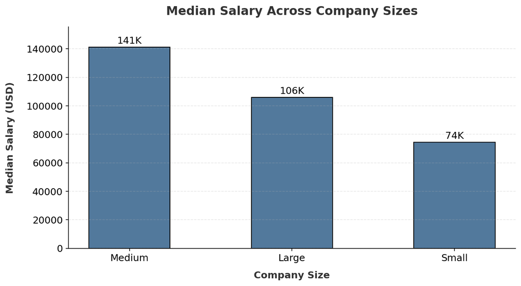

```python
#step02: Visualized median salary across different company sizes using a bar chart

# Data
x = median_salary_company_size["company_size"]
y = median_salary_company_size["median_salary"]

# Create figure
plt.figure(figsize=(10, 5), dpi=150)

# Bar plot
plt.bar(x, y, width=0.5, edgecolor="black", color="#52799C")

# Titles and labels
plt.title(
    "Median Salary Across Company Sizes",
    color="#333333",
    fontweight="bold",
    fontsize=15,
    pad=15
)
plt.xlabel("Company Size", fontweight="bold", fontsize=12, labelpad=10, color="#333333")
plt.ylabel("Median Salary (USD)", fontweight="bold", fontsize=12, labelpad=14, color="#333333")

# Axis formatting
plt.xticks(fontsize=12)
plt.yticks(fontsize=12)

# Add value labels (formatted as K)
for i, v in enumerate(y):
    label = f"{v/1000:.0f}K"
    plt.text(
        i,
        v + max(y) * 0.008,
        label,
        ha='center',
        va='bottom',
        fontsize=12
    )

# Styling improvements
plt.ylim(0, max(y) * 1.1)
plt.margins(y=0.05)
plt.grid(axis='y', linestyle='--', alpha=0.3)

# Remove unnecessary borders
plt.gca().spines['top'].set_visible(False)
plt.gca().spines['right'].set_visible(False)
# Show plot
plt.show()
```

KEY INSIGHTS OF EDA SECTION 14:

- Medium-sized companies not only hire the most (EDA 13) but also offer the highest median salary, making them the strongest overall option
- Large companies provide the second highest median salary, but still pay less than medium-sized companies
- Small companies have both the lowest hiring and lowest median salary, showing limited opportunities and lower pay

EDA SECTION 15: Employment Type Distribution (Full-time / Contract / Part-time)

- This section analyzes how jobs are split across Full-time, Contract, and Part-time roles
- The goal is to identify which employment type is most common in the data job market
- This helps understand overall hiring preference for different job types in the industry

```python
#step01: Calculated job count for each employment type

employment_distribution = (
                clean_dataset
                .groupby("employment_type")
                .size()
                .reset_index(name="job_count")
                .sort_values("job_count", ascending=False))

employment_distribution
```

|  | employment_type | job_count |
| --- | --- | --- |
| 2 | Full-time | 6543 |
| 0 | Contract | 19 |
| 3 | Part-time | 16 |
| 1 | Freelance | 12 |

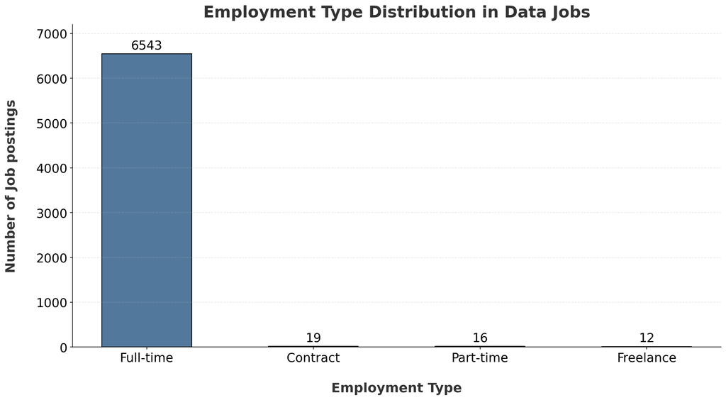

```python
#step02: Visualized employment type distribution to identify the most preferred job type in the data job market

# Data
x = employment_distribution["employment_type"]
y = employment_distribution["job_count"]

# Wrap long labels for better readability
import textwrap
wrapped_labels = [textwrap.fill(label, 12) for label in x]

# Create positions to increase spacing between bars
pos = np.arange(len(x)) * 1.3   # adjust (1.3–1.5) for more spacing

# Create figure
plt.figure(figsize=(16, 8), dpi=150)

# Bar plot
plt.bar(pos, y, width=0.7, edgecolor="black", color="#52799C")

# Titles and labels
plt.title(
    "Employment Type Distribution in Data Jobs",
    color="#333333",
    fontweight="bold",
    fontsize=22,
    pad=10
)
plt.xlabel("Employment Type", fontweight="bold", fontsize=18, labelpad=25, color="#333333")
plt.ylabel("Number of Job postings", fontweight="bold", fontsize=18, labelpad=25, color="#333333")

# Axis formatting
plt.xticks(pos, wrapped_labels, fontsize=17)
plt.yticks(fontsize=17)

# Add value labels
plt.bar_label(plt.gca().containers[0],
            fontsize=17,
            padding=3)

# Styling improvements
plt.ylim(0, max(y) * 1.1)
plt.margins(y=0.05)
plt.grid(axis='y', linestyle='--', alpha=0.3)

# Remove unnecessary borders
plt.gca().spines['top'].set_visible(False)
plt.gca().spines['right'].set_visible(False)

# Show plot
plt.show()
```

KEY INSIGHTS OF EDA SECTION 15:

- Full-time jobs dominate the data job market, showing very high demand for permanent roles
- Contract, Part-time, and Freelance roles are very limited compared to Full-time jobs
- The data industry strongly prefers stable long-term employment over flexible work types

EDA SECTION 16: Final Insights & Summary